# Practice with functions

Part 1

Module 4 A3 Week 4

## Body temperature data

A recent paper, [Decreasing human body temperature in the United States since the Industrial Revolution](https://elifesciences.org/articles/49555), presented evidence that human body temperatures in the United States have been decreasing over the past one hundred or so years. (Many scientists dispute the conclusions of the paper.) One of the data sets in the paper is taken from the NHANES (National Health and Nutrition Examination Study), and is available in the file `NHANES_processed.csv`. There are many variables in the data, but our focus will be on the variable `temp` that provides resting oral body temperatures.

1. Draw a histogram of the body temperature variable

```r
library(ggplot2)
data = read.csv(file = "NHANES_processed.csv")
head(data)
```

```
  X  V1               study_ID sample_weights temp time_HR  race    sex age
1 1 Inf NH_8055200100001427111           1645 98.4      NA white female  39
2 2 Inf NH_8055200100002427111           3318 98.0      NA white   male  61
3 3 Inf NH_8055200100003427111           2280 99.0      NA black female  25
4 4 Inf NH_8055200100004427111           1574 98.4      NA black female  24
5 7 Inf NH_8055200100007427111           1627 98.2      NA black female  35
6 8 Inf NH_8055200100008427112          14604 97.6      NA white female  35
  year_of_birth  exam_date exam_year exammonth exam_findings exam_ICD exam_ICD2
1          1931 1971-05-20      1971         5             2     9999      9999
2          1909 1971-05-22      1971         5             2     9999      9999
3          1946 1971-04-28      1971         4             2      401      9999
4          1946 1971-05-12      1971         5             2     9999      9999
5          1935 1971-05-19      1971         5             2     9999      9999
6          1935 1971-04-28      1971         4             2      401      9999
     region birth_cohort head_eyes_ears_nose_findings thyroid_findings
```

[output cut: 34 more lines]

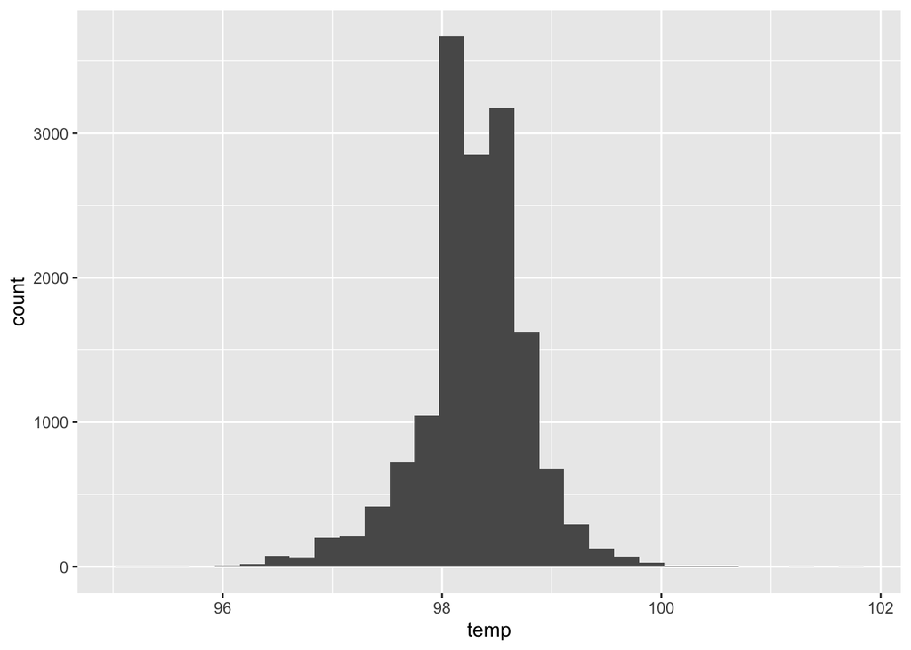

```r
ggplot(data, aes(x = temp)) + geom_histogram()
```

The *empirical cumulative distribution function* (ecdf) gives the proportion of data values at or below a particular value. In the case of the body temperature data, $\text{ecdf}(98.1)$, for example, gives the proportion of temperatures in the data set below $98.1$ degrees. A few minutes of thought reveals that

- $\text{ecdf}(x) = 0$ if $x$ is less than the minimum temperature in the data set;
- $\text{ecdf}(x) = 1$ if $x$ is greater than or equal to the maximum temperature in the data set;
- $\text{ecdf}(x)$ is a non-decreasing function of $x$.
2. Use the `stat_ecdf` function in `ggplot2` to draw an “empirical cumulative distribution function” for the body temperature variable.

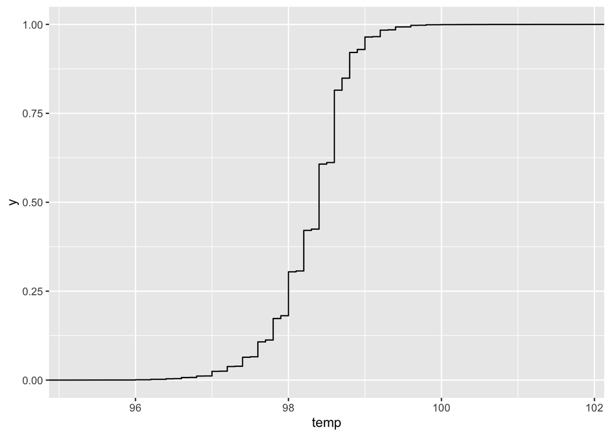

```r
ggplot(data, aes(x = temp)) + stat_ecdf()
```

Look at the plot of the ecdf to gain more insight into the behavior of the ecdf.

3. Estimate the 25th, 50th, and 75th percentiles of the temperature data from the ecdf plot. How do these compare with the percentiles computed via the `summary()` function?

```r
quantile(data$temp)
```

```
   0%   25%   50%   75%  100%
 95.2  98.0  98.4  98.6 101.8
```

```r
summary(data$temp)
```

```
   Min. 1st Qu.  Median    Mean 3rd Qu.    Max.
  95.20   98.00   98.40   98.31   98.60  101.80
```

```r
#it looks like the same percentiles are given in both functions
```

4. How does the mean temperature compare to the median temperature?

```r
mean(data$temp)
```

```
[1] 98.30529
```

```r
median(data$temp)
```

```
[1] 98.4
```

```r
#the mean and median of the temperatures is very close.
```

## Name data

The file `CensusNames.csv` contains data on surnames in the United States, including the name, the rank of the name among all names, and the number of people in the United States with that name. (Some uncommon names are not included in the data.)

5. Is your surname in the list? If so, what is its rank, and how many people in the United States have that name?

```r
census = read.csv("CensusNames.csv")
head(census)
```

```
      name rank   count
1    SMITH    1 2442977
2  JOHNSON    2 1932812
3 WILLIAMS    3 1625252
4    BROWN    4 1437026
5    JONES    5 1425470
6   GARCIA    6 1166120
```

```r
"NGUYEN" %in% census$name
```

```
[1] TRUE
```

```r
census[census$name == "NGUYEN",]
```

```
     name rank  count
38 NGUYEN   38 437645
```

```r
#Yes, ranked 38 with 437,645 people
```

6. Draw a histogram and an ecdf plot of the variable which counts the number of people with a name. What do you notice from these plots?

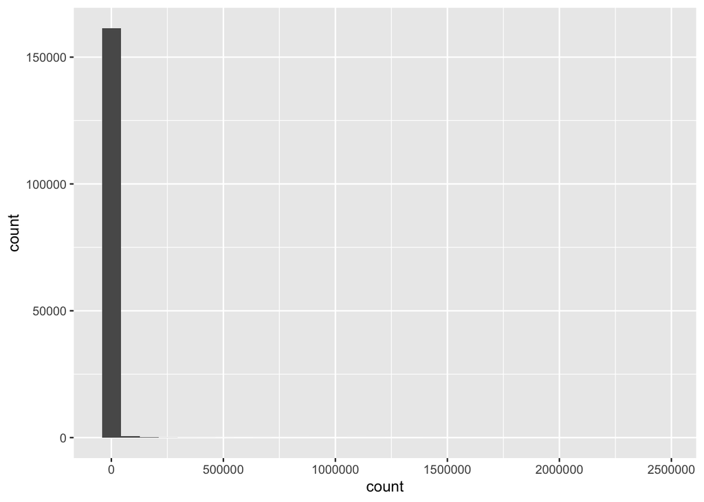

```r
ggplot(census, aes(x = count)) + geom_histogram()
```

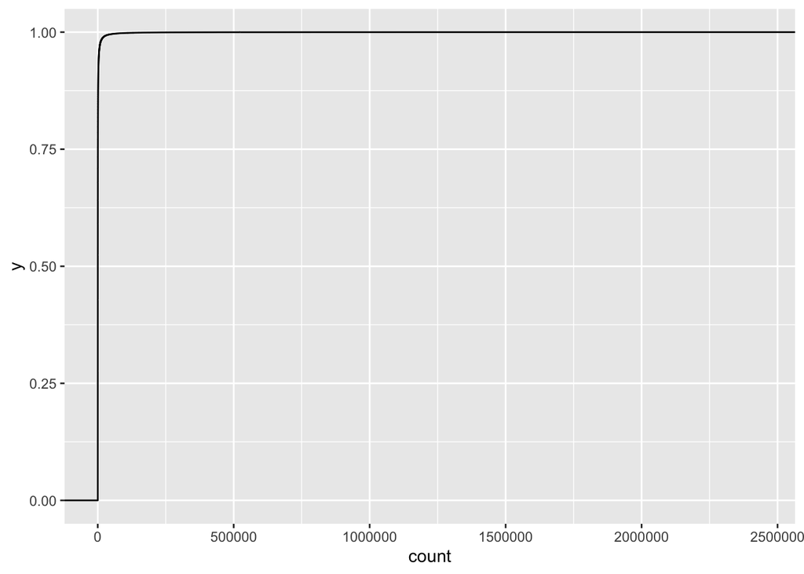

```r
ggplot(census, aes(x = count)) + stat_ecdf()
```

```r
#The data is very skewed towards the upper ranks (Just as Benfords law states!)
```

7. Draw a histogram and an ecdf plot of the base 10 logarithm of the counts. The R function `log10()` computes base 10 logarithms.

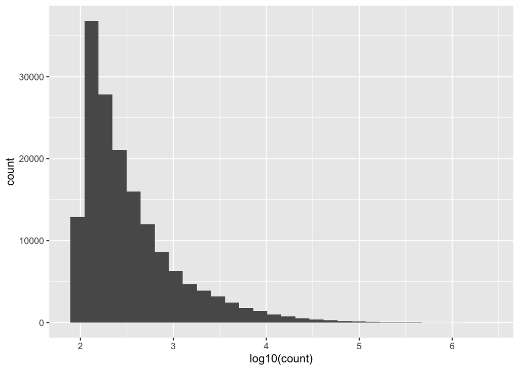

```r
ggplot(census, aes(x = log10(count))) + geom_histogram()
```

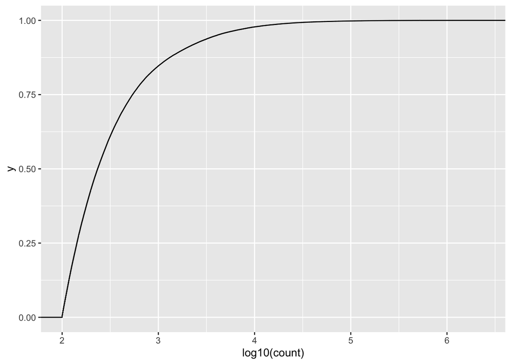

```r
ggplot(census, aes(x = log10(count))) + stat_ecdf()
```

8. From the ecdf plot of the logarithm of the counts, estimate the 25th, 50th, and 75th percentiles of the counts. Compare these to the computed percentiles from the `summary()` function. Are they similar?

```r
#25th = 2.2, 50th = 2.4, 75th = 2.6

summary(log10(census$count))
```

```
   Min. 1st Qu.  Median    Mean 3rd Qu.    Max.
  2.000   2.152   2.369   2.530   2.732   6.388
```

```r
quantile(log10(census$count))
```

```
      0%      25%      50%      75%     100%
2.000000 2.152288 2.369216 2.731589 6.387919
```

```r
#The values are similar, just hard to hand read the graph
```

9. How does the mean count compare to the median count? How does the mean count compare to the 75th percentile of the counts?

```r
#the distance between he mean and median and mean and 75th are roughly the distance away from each other. pretty close relative to the range of the data set.
```

## US cities data

**Extra practice: This section isn’t very different from the previous section. Complete it later for your practice.(not graded)**

The file `UnitedStatesCities.csv` contains data on cities in the United States, including the name of the city, the population rank of the city among all cities, and the number of people living in the city in 2010.

10. What are the population and rank of East Lansing?
11. Draw a histogram and an ecdf plot of the populations. Do these data seem more like the data on body temperatures or the data on the count of people with a particular name?
12. Draw a histogram and an ecdf plot of the base-10 logarithm of the populations.
13. From the ecdf plot of the logarithm of the populations, estimate the 25th, 50th, and 75th percentiles of the populations. Compare these to the computed percentiles from the `summary()` function. Are they similar?
14. How does the mean population compare to the median population? How does the mean count compare to the 75th percentile of the populations?